# PSTAT 174/274: Homework # 1

Dylan Berneman

2023-04-14

This homework is based on Lectures 1–2. Please study material of week 1 before starting working on this problems. Good Luck!

#### Question 1

*Understanding deterministic and stochastic trends.* You are given the following statements about time series:

- 1. Stochastic trends are characterized by explainable changes in direction.
- 2. Deterministic trends are better suited to extrapolation than stochastic trends.
- 3. Short term extrapolation of deterministic trends can be justified by claiming that underlying trends will usually change slowly in comparison with the forecast lead time.

Determine which statements are true. Explain.

A. I only  
B. II only  
C. III only  
D. I, II, and III  
E. The answer is not given by (A), (B), (C), or (D).

1. False. Stochastic trends are characterized by unexplainable changes in direction. They arise from the random movement of the variable over time.
2. True. Deterministic trends are a result of the constant effect of a few causal forces an are generally stable over time.
3. True. Deterministic trends can provide accurate forecasts for several periods ahead, as forecasting generally assumes that trends will continue and change relatively slowly.

#### Question 2

*Random walk and stationarity. In this question we introduce WN and random walk with non-zero mean. A White Noise with non-zero mean*  
Z<sub>t</sub> ∼ WN(μ<sub>Z</sub>, σ<sup>2</sup><sub>Z</sub>), *is a collection of uncorrelated random variables with the same mean and variance:* E(Z<sub>t</sub>) = μ<sub>Z</sub>, Var(Z<sub>t</sub>) = σ<sub>Z</sub><sup>2</sup>, and Cov(Z<sub>t</sub>, Z<sub>s</sub>) = 0 for t $\ne$ s. *When* Z<sub>t</sub> *is referred to as a ‘White Noise’, without specifying its mean, by default, assume* μ<sub>Z</sub> = 0. *A random walk with non-zero mean is expressed as* X<sub>1</sub> =Z<sub>1</sub>, X<sub>t</sub> = X<sub>t−1</sub> + Z<sub>t</sub> = Z<sub>1</sub>+…+Z<sub>t</sub>, t=2,3,…, *where* Z<sub>t</sub> ∼WN(μ<sub>Z</sub>, σ<sub>Z</sub><sup>2</sup>).  
Determine which statements are true with respect to a random walk model; show calculations and provide complete explanations.

- 1. If μ<sub>Z</sub> $\neq$ 0, then the random walk is nonstationary in the mean.  
     *(Hint: Nonstationary in the mean means that the mean changes with time.)*
- 2. If σ<sub>Z</sub><sup>2</sup> = 0, then the random walk is nonstationary in the variance.  
     *(Hint: Nonstationary in the variance means that the variance changes with time.)*
- 3. If σ<sub>Z</sub><sup>2</sup> > 0, then the random walk is nonstationary in the variance.

```
I. True.
```

For all t where t $\ge$ 1, E[X<sub>t</sub>] = E[X<sub>t-1</sub>] + Z<sub>t</sub>

$$\begin{align*}
E[Z_{t}] & = E[Z_{1}] = E[Z_{2}] = E[Z_{t-1}] = E[Z_{t}]
= \mu_{Z} \\
E[X_{t}] & = E[Z_{1}] + E[Z_{2}] + ... E[Z_{t-1}] + E[Z_{t}] \\
& = tE[Z_{t}] \\
& = t\mu_{Z} \\
\end{align*}$$
$$\begin{aligned}
& E[X_{1}] = E[Z_{1}] = \mu_{Z}\\
& E[X_{2}] = E[X_{1}] + E[Z_{2}] = 2\mu_{Z}\\
& E[X_{t-1}] = E[X_{t-2}] + E[Z_{t-1}] = (t-1)\mu_{Z}\\
& E[X_{t}] = E[X_{t-1}] + E[Z_{t}] = t\mu_{Z}\\ \\
& Therefore,\ E[X_{1}] \neq E[X_{2}] \neq E[X_{t-1}] \neq E[X_{t}]
\end{aligned}$$

Since $\mu_{Z} > 0\ \ or \ \ \mu_{Z} < 0,\ X_{t}$ either increases or decreases by increments of $\mu_{Z}$  
Thus the random walk is nonstationary in the mean.

```
II. False
```

$$\begin{aligned}
& \text{It is given that}\ σ_{Z}^2=0\ \ \ \ \& \ \ \ Cov(Z_{t},
Z_{s}) =0,\ for\ t \ne s
\end{aligned}$$
$$\begin{aligned}
For\ all\ &t\ \ge 1,\ Var[X_{t}] = Var[X_{t-1} + Z_{t}]\\
Var[Z_{t}] & = Var[Z_{1}] = Var[Z_{2}] = Var[Z_{t-1}] = Var[Z_{t}]
= \sigma^2_{Z} =0 \\ \\
Var[X_{1}]& = Var[Z_{1}] = \sigma^2_{Z} = 0\\
Var[X_{2}]& = Var[X_{1} + Z_{2}] \\
&= Var[X_{1}] + Var[Z_{2}] + 2Cov[X_{1}, Z_{2}]\\
&= Var[X_{1}] + Var[Z_{2}] + 2Cov[Z_{1}, Z_{2}]\\
&= 0 + 0 + 2(0)\\
&=0\\
Var[X_{t-1}]& = Var[X_{t-2} + Z_{t-1}] \\
&= Var[X_{t-2}] + Var[Z_{t-1}] + 2Cov[X_{t-2}, Z_{t-1}]\\
&= Var[X_{t-2}] + Var[Z_{t-1}] + 2Cov[Z_{t-2}, Z_{t-1}]\\
&= 0 + 0 + 2(0)\\
&=0\\
Var[X_{t}]& = Var[X_{t-1} + Z_{t}] \\
&= Var[X_{t-1}] + Var[Z_{t}] + 2Cov[X_{t-1}, Z_{t}]\\
&= Var[X_{t-1}] + Var[Z_{t}] + 2Cov[Z_{t-1}, Z_{t}]\\
&= 0 + 0 + 2(0)\\
&=0\\
& Therefore,\ Var[X_{1}] = Var[X_{2}] = Var[X_{t-1}] = Var[X_{t}]\\
& \text{Thus, the random walk is stationary in the variance}\\
& \text{because the variance remains constant as t changes.}
\end{aligned}$$

```
III. True
```

$$\text{It is given that}\
σ_{Z}^2>0\ \ \ \ \& \ \ \ Cov(Z_{t}, Z_{s}) =0,\ for\ t \ne
s$$
$$\begin{aligned}
For\ all\ &t\ \ge 1,\ Var[X_{t}] = Var[X_{t-1} + Z_{t}]\\
Var[Z_{t}] & = Var[Z_{1}] = Var[Z_{2}] = Var[Z_{t-1}] = Var[Z_{t}]
= \sigma^2_{Z} \\ \\
Var[X_{1}]& = Var[Z_{1}] = \sigma^2_{Z}\\
Var[X_{2}]& = Var[X_{1} + Z_{2}] \\
&= Var[X_{1}] + Var[Z_{2}] + 2Cov[X_{1}, Z_{2}]\\
&= Var[Z_{1}] + Var[Z_{2}] + 2Cov[Z_{1}, Z_{2}]\\
&= \sigma^2_{Z} + \sigma^2_{Z} + 2(0)\\
&= 2\sigma^2_{Z} \\ \\
& \text{This implies that}\ Var[X_{2}] = 2Var[X_{1}] = 2Var[Z_{1}]\\
\\
Var[X_{3}]& = Var[X_{2} + Z_{3}] \\
&= Var[X_{2}] + Var[Z_{3}] + 2Cov[X_{2}, Z_{3}]\\
&= 2Var[Z_{2}] + Var[Z_{3}] + 2Cov[2*Z_{2}, Z_{3}]\\
&= 2\sigma^2_{Z} + \sigma^2_{Z} + 2(2)(0)\\
&= 3\sigma^2_{Z} \\ \\
Var[X_{t}]& = Var[X_{t-1} + Z_{t}] \\
&= Var[X_{t-1}] + Var[Z_{t}] + 2Cov[X_{t-1}, Z_{t}]\\
&= 2Var[Z_{t-1}] + Var[Z_{t}] + 2Cov[(t-1)*Z_{t-1}, Z_{t}]\\
&= (t-1)\sigma^2_{Z} + \sigma^2_{Z} + 2(t-1)(0)\\
&= t\sigma^2_{Z} \\ \\
& \text{Therefore},\ Var[X_{1}] \ne Var[X_{2}] \ne Var[X_{3}] \ne
Var[X_{t}]\\
& \text{Thus, the random walk is nonstationary in the variance}\\
& \text{because the variance increases by increments of}\
Var[Z_{t}]\ \text{as t changes}.
\end{aligned}$$

#### Question 3

*Calculation of sample acf.* You are given the following stock prices of company CAS:

| Day | Stock Price |
| --- | --- |
| 1 | 538 |
| 2 | 548 |
| 3 | 528 |
| 4 | 608 |
| 5 | 598 |
| 6 | 589 |
| 7 | 548 |
| 8 | 514 |
| 9 | 501 |
| 10 | 498 |

Calculate the sample autocorrelation at lag 3.  
*Hints:*

*(i) We are given a sample of size n = 10 to estimate autocorrelation at lag 3:* ρ(3) = Cor(X<sub>1</sub>, X<sub>4</sub>) = $\frac{γ(3)}{γ(0)}$
*– for definition of autocorrelation at lag 3 see Week 1 slide 52 or (2.1.3) on p.6 of Lecture Notes.*
*(ii) General formulas for calculating sample mean and covariance are given on slide 38 of week 1 and in §1.2 on p.4 of Lecture notes for week 1.* *To estimate* ρ(3) = Cor(X<sub>1</sub>, X<sub>4</sub>) *we have:*
$$\bar{x}=\frac{1}{n} \sum_{t=1}^n x_t, \quad
\hat{\rho}_3=\frac{\hat{\gamma}(3)}{\hat{\gamma}(0)}=\frac{\sum_{t=1}^{n-3}\left(x_t-\bar{x}\right)\left(x_{t+3}-\bar{x}\right)}{\sum_{t=1}^n\left(x_t-\bar{x}\right)^2}$$

```r
data = data.frame(matrix(ncol=5, nrow=10))
colnames(data)<-c("Day", "SP ($x_{t}$)", "$(x_{t}- \\bar{x})$", "$(x_{t}- \\bar{x})^2$", "$(x_{t}- \\bar{x})(x_{t+3}\ \ - \ \\bar{x})$")

data$Day <- c(seq(1,10))
data[,2] <- c(538, 548, 528, 608, 598, 589, 548, 514, 501, 498)

mean = mean(data[,2])
for(i in 1:10){
  data[i,3] = data[i,2] - mean}

for(i in 1:10){
  data[i,4] = (data[i,2] - mean)^2}

data[,5] <- NA
for(i in 1:7){
  data[i,5] = data[i, 3] * data[i+3, 3]}

data[11,1] <- "total"
data[11,2] <- sum(as.integer(data[1:10, 2]))
data[11,3] <- sum(as.integer(data[1:10, 3]))
data[11,4] <- sum(as.integer(data[1:10, 4]))
data[11,5] <- sum(as.integer(data[1:7, 5]))
knitr::kable(data)
```

| Day | SP ($x_{t}$) | $(x_{t}- \bar{x})$ | $(x_{t}- \bar{x})^2$ | $(x_{t}- \bar{x})(x_{t+3} - \bar{x})$ |
| --- | --- | --- | --- | --- |
| 1 | 538 | -9 | 81 | -549 |
| 2 | 548 | 1 | 1 | 51 |
| 3 | 528 | -19 | 361 | -798 |
| 4 | 608 | 61 | 3721 | 61 |
| 5 | 598 | 51 | 2601 | -1683 |
| 6 | 589 | 42 | 1764 | -1932 |
| 7 | 548 | 1 | 1 | -49 |
| 8 | 514 | -33 | 1089 | NA |
| 9 | 501 | -46 | 2116 | NA |
| 10 | 498 | -49 | 2401 | NA |
| total | 5470 | 0 | 14136 | -4899 |

```r
# Autocorrelation
data[11,5] / data[11,4]
```

```
## [1] -0.346562
```

#### Question 4

*Polyroot command in R. Recall from algebra, that a function* f(z) = a<sub>n</sub>z<sup>n</sup> + a<sub>n−1</sub>z<sup>n−1</sup> + … + a<sub>1</sub>z + a<sub>0</sub> *is called a polynomial function of order n. Roots of a polynomial function f are solutions of the equation* f(z) = 0.  
*Roots of a quadratic equation* ax<sup>2</sup> + bx + c = 0 *are given by the formula* x<sub>1,2</sub> = $\frac{−b ± \sqrt{b^2−4ac}}{2a}$  
Let f(z) = 1 − 2z and g(z) = 1 − 0.45z + 0.05z<sup>2</sup>. Find their roots, show calculations.  
Check your answers using R command *polyroot*:

> *polyroot*(c(1, −2))  
> *polyroot*(c(1, −0.45, 0.05))  
*(Do not forget to include your output!)*

$$\begin{aligned}
f(z) = 1 - 2z\\
1-2z=0\\
1 = 2z\\
z = 0.5
\end{aligned}$$

$$\begin{aligned}
&\text{To solve for the roots of a second degree polynomial of the
form:} \\
& f(x) = ax^2 + bx + c,\\
& \text{Calculate the following:}\\ \\
&x = \frac{-b\ \pm \sqrt{b^2\ -\ 4ac}}{2a}\\ \\
&g(z) = 1 - 0.45z + 0.05z^2= 0\\
&a = 0.05,\ \ b = -0.45,\ \ c = 1 \\
\\
&z=\frac{-(-0.45)\ \pm \sqrt{(-0.45)^2\ -\ (4(0.05)(1)}}{2(0.05)}\\
\\
& \ \ =\ \frac{0.45\ \pm \sqrt{0.2025\ -\ 0.2}}{0.1}\\ \\
& \ \ =\ \frac{0.45\ \pm \sqrt{0.0025}}{0.1}\\ \\
& \ \ =\frac{0.45\ \pm 0.05}{0.1}\\ \\
&z =
\left\{
\begin{array}{lr}
0.4/0.1 \\
0.5/0.1\\
\end{array}
\right\} \\
&z = 4\ or\ 5
\end{aligned}$$

```r
vect1 <- vector()
vect1 <- append(vect1, 1)
vect1 <- append(vect1, -2)

vect2 <- vector()
vect2 <- append(vect2, 1)
vect2 <- append(vect2, -0.45)
vect2 <- append(vect2, 0.05)

polyroot(vect1)
```

```
## [1] 0.5+0i
```

```r
polyroot(vect2)
```

```
## [1] 4+0i 5-0i
```

#### Question 5

*Model identification.* You are given the following information about a MA(1) model with coefficient |θ<sub>1</sub>| < 1: ρ<sub>1</sub> = −0.4, ρ<sub>k</sub> = 0, k = 2,3,….  
Determine the value of θ<sub>1</sub>.

$$\begin{aligned}
& \rho(1) = \frac{\theta_{1}}{(1+\theta^2_{1})}\\
& \rho(1)(1+\theta^2_{1})-\theta_{1} = 0\\
& \rho(1) = -0.4\\
& -0.4(1+\theta^2_{1})-\theta_{1} = 0\\
& -2(1+\theta^2_{1}) - 5\theta_{1}=0\\
& 2(1+\theta^2_{1}) + 5\theta_{1}=0\\
& 2\ \theta^2_{1} + 5\theta_{1} + 2 = 0\\
& \frac{-5\ \pm\ \sqrt{5^2-4(2)(2)}}{2(2)} \\ \\
& \frac{-5\ \pm\ 3}{2(2)}\\ \\
& -8/4 = -2 \\
& -2/4 = -0.5
\\
\\
&\text{Given}\ |\ \theta_{1}\ |\ < 1,\\
&\theta_{1} = -0.5
\end{aligned}$$

#### Question 6

*Gaussian White Noise and its square.* Let {Z<sub>t</sub>} be a Gaussian white noise, that is, a sequence of i.i.d. normal r.v.s each with mean zero and variance 1. Let Y<sub>t</sub> = Z<sub>t</sub><sup>2</sup>.

1. Using R generate 300 observations of the Gaussian white noise Z. Plot the series and its acf.
2. Using R, plot 300 observations of the series Y = Z<sub>t</sub><sup>2</sup>. Plot its acf.
3. Analyze graphs from (a) and (b).  
   – Can you see a difference between the plots of graphs of time series Z and Y? From the graphs, would you conclude that both series are stationary (or not)?  
   – Is there a noticeable difference in the plots of acf functions ρ<sub>Z</sub> and ρ<sub>Y</sub>? Would you describe Y as a non-Gaussian white noise sequence based on your plots? Provide full analysis of your conclusions.
4. Calculate the second-order moments of Y: μ<sub>Y</sub> (t) = E(Y<sub>t</sub>), σ<sub>Y</sub><sup>2</sup> (t) = Var(Y<sub>t</sub>), and ρ<sub>Y</sub>(t, t + h) = Cor(Y<sub>t</sub>, Y<sub>t+h</sub>).  
   Do your calculations support your observations in (c)?

*Hints:*

*(i) Slides 65 and 68 of week 1 have R commands to generate MA(1) time series. White Noise is a MA(1) process with coefficient θ<sub>1</sub> = 0.*  
*Here is a more direct code to generate* WN{Z<sub>t</sub>} ∼ N(0,1):

Z <= rnorm(300)  
plot.ts(Z, xlab = ””, ylab = ””) acf(Z, main = ”ACF”)

*(ii) Useful for part (d): For* X ∼ N(0,σ<sup>2</sup>), E(X<sub>4</sub>) = 3(σ<sup>2</sup>)<sup>2</sup>.

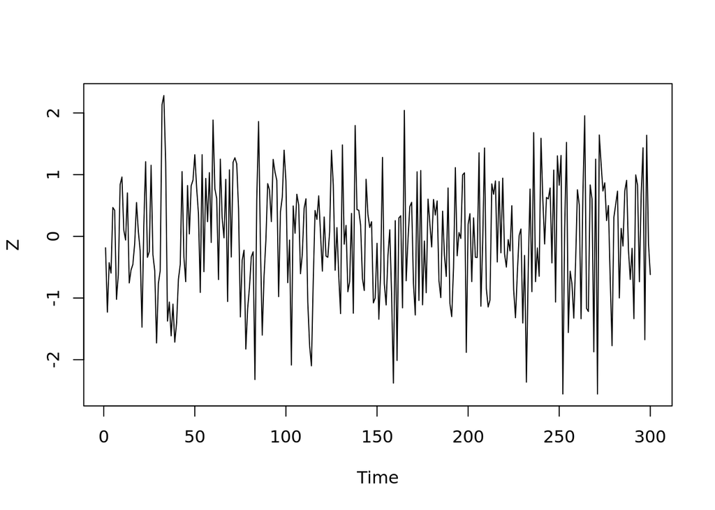

```r
set.seed(39)
Z = rnorm(300, 0, 1)
Y=Z^2
ts.plot(Z)
```

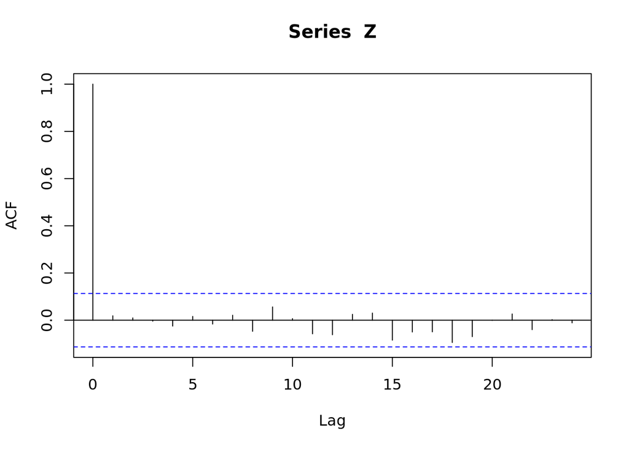

```r
acf(Z)
```

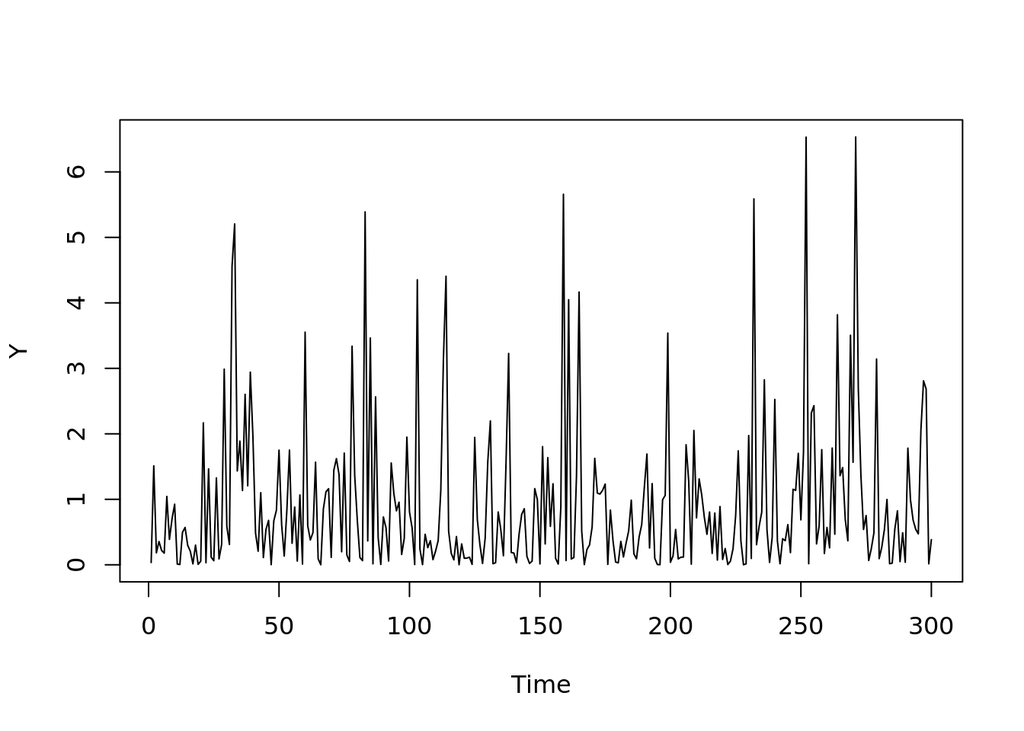

```r
set.seed(39)
ts.plot(Y)
```

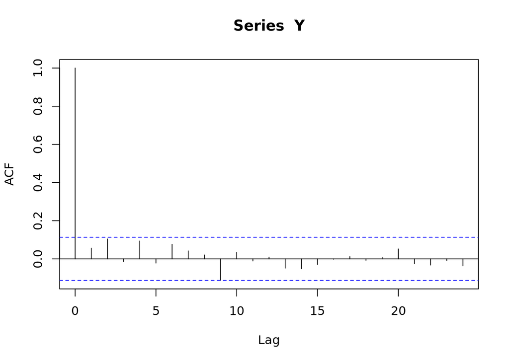

```r
acf(Y)
```

3. Just by looking at both time series plots, I could tell that they were both stationary because the majority of the values fall on a horizontal line. For the plot of Z, the horizontal line looks to be at y=0, while the plot of Y looks to have a horizontal line at y=1. Also, neither plot seems to have seasonality. For the plots of the acf of both Y and Z, it appears that Y has larger spikes then Z, which makes sense because Y = $Z^2$. In addition, the acf of Z appears to come from a gaussian white noise distribution because its spikes are all within the blue dotted lines.
4. $$\begin{aligned}
   & Z = N(0,1)\\
   & Y = Z_{t}^2\\
   E[Y] & = µ_{y}(t)\\
   E[Y] & = E[Z_{t}^2]\\
   & = Var[Z_{t}]+E[Z_{t}]^2\\
   & = 0 + 1\\
   &=1
   \end{aligned}$$

$$\begin{aligned}
For\ X &= N(0,\sigma^2),\ E[X^4]=3(\sigma^2)^2\\
Var[Y] & = \sigma^2_{y}(t)\\
Var[Y] & = Var[Z_{t}^2]\\
& = E[(Z_{t}^2)^2]-E[Z_{t}^2]^2\\
& = E[Z_{t}^4]-E[Z_{t}^2]^2\\
& = 3(1)^2 - 1^2\\
& = 2\\
\end{aligned}$$
/

$$\begin{aligned}
& Assuming\ h=0\\
& If\ Cov(Z_{t},\ Z_{s})=0\ for\ t \ne s\ \rightarrow\ Cov(Z^2_{t},\
Z^2_{s})=0\\
&\rho_{Y}(t, t+h)=Cor(Y_{t}, Y_{t+h})\\ \\
&Cor(Y_{t}, Y_{t+h}) = \frac{Cov(Y_{t},
Y_{t+h})}{\sqrt{Var(Y_{t})*Var(Y_{t+h})}}\\ \\
& \ \ \ \ \ \ \ \ \ \ \ \ \ \ \ \ \ \ \ \ \ \ = \frac{Cov(Z^2_{t},\
Z^2_{t+h})}{\sqrt{Var(Y_{t})*Var(Y_{t+h})}}\\ \\
& \ \ \ \ \ \ \ \ \ \ \ \ \ \ \ \ \ \ \ \ \ \ =
\frac{0}{\sqrt{2*2}}\\ \\
& \ \ \ \ \ \ \ \ \ \ \ \ \ \ \ \ \ \ \ \ \ \ = 0
\end{aligned}$$

**The following two problems are for students enrolled in PSTAT 274 ONLY**

#### Question G1

Let {Zt} be *Gaussian* white noise, i.e. {Z<sub>t</sub>} is a sequence of i.i.d. normal r.v.s each with mean zero and variance 1.

Define: $X_t= \begin{cases}Z_t, & \text { if } t \text { is even } \\ \left(Z_{t-1}^2-1\right) / \sqrt{2}, & \text { if } t \text { is odd }\end{cases}$

Show that {X<sub>t</sub>} is WN(0, 1) (that is, variables X<sub>t</sub> and X<sub>t+k</sub>, k ≥ 1, are uncorrelated with mean zero and variance 1) but that X<sub>t</sub> and X<sub>t−1</sub> are **not** i.i.d.

$$\begin{align*}
Z_{t} \sim WN(0, 1)
\end{align*}$$

$$X_t= \begin{cases}Z_t, & \text { if } t \text { is even } \\
\left(Z_{t-1}^2-1\right) / \sqrt{2}, & \text { if } t \text { is odd
}\end{cases}$$

$$\begin{align*}
\text{If t is even}:&\\
& E[X_{t}] = E[Z_{t}]\\
&\ \ \ \ \ \ \ \ \ \ = 0\\
\text{If t is odd}:&\\
& E[X_{t}] = E[(Z^2_{t-1}-1)/\sqrt{2}]\\
&\ \ \ \ \ \ \ \ \ \ = \sqrt{2}\ (E[Z^2_{t-1}]-1)\\
&\ \ \ \ \ \ \ \ \ \ = \sqrt{2}\ (Var[Z_{t-1}]+E[Z_{t-1}]^2-1)\\
&\ \ \ \ \ \ \ \ \ \ = \sqrt{2}\ (1+(0)^2-1)\\
&\ \ \ \ \ \ \ \ \ \ = 0
\end{align*}$$

$$\begin{align*}
\text{If t is even}:&\\
& Var[X_{t}] = Var[Z_{t}]\\
&\ \ \ \ \ \ \ \ \ \ \ \ \ \ = 1\\
\text{If t is odd}:&\\
& Var[X_{t}] = Var[(Z^2_{t-1}-1)/\sqrt{2}]\\
&\ \ \ \ \ \ \ \ \ \ \ \ \ \ = \frac{1}{2}\ (Var[Z^2_{t-1}])\\
&\ \ \ \ \ \ \ \ \ \ \ \ \ \ = \frac{1}{2}\
(E[Z_{t-1}^4]-E[Z^2_{t-1}]^2])\\
&\ \ \ \ \ \ \ \ \ \ \ \ \ \ = \frac{1}{2}\
(3(Var[Z_{t-1}])^2-(Var[Z_{t-1}]-E[Z_{t-1}])^2)\\
&\ \ \ \ \ \ \ \ \ \ \ \ \ \ = \frac{1}{2}\ (3(1)^2-(1-0^2)^2)\\
&\ \ \ \ \ \ \ \ \ \ \ \ \ \ = \frac{1}{2}\ (2)\\
&\ \ \ \ \ \ \ \ \ \ \ \ \ \ = \ 1\\
\end{align*}$$

$$\begin{align*}
& \text{Let t be even and h be odd} \\
&Cor(X_{t}, X_{t+h}) = \frac{Cov(X_{t},
X_{t+h})}{\sqrt{Var(X_{t})*Var(X_{t+h})}}\\ \\
&\text{Since}\ X_{t}\ \ \&\ \ X_{t+h}\ \ \text{are both from the
distribution WN(0,1)} \\
& \ \ \ \ \ \ \ \ \ \ \ \ \ \ \ \ \ \ \ \ \ \ \ \ \ \ \ \ \ \ \ \ \
\ \ \ \ \ \ \ \ \& \\
& \ \ \ \ \ \ \ \ \ \ Cov[(WN_{t}(0,1),\ WN_{s}(0,1)]=0\ for\ t \ne
s\ \\ \\
& \ \ \ \ \ \ \ \ \ \ \text{Then}\ \ Cov(X_{t}, X_{t+h})=0 \\
& \ \ \ \ \ \ \ \ \ \ \ \ \ \ \ \rightarrow Cor(X_{t}, X_{t+h}) =
0\\ \\
&\text{Thus,}\ X_{t}\ \text{and}\ X_{t+h}\ \text{are
uncorrelated}.\\
&\text{But because}\ X_{t+h} = (Z^2_{t-1+h}-1)/\sqrt{2}\ \text{and}\
Z^2_{t-1+h}\ \text{is dependent on}\ Z_{t+h-1,}\\
&\text{then}\ X_{t+h}\ \text{is also dependent on}\ X_{t+h-1}. \\
&\text{Therefore,}\ X_{t}\ \text{and}\ X_{t+h}\ \text{are not i.i.d.
variables.}
\end{align*}$$

#### Question G2

If {X<sub>t</sub>} and {Y<sub>t</sub>} are uncorrelated stationary sequences, i.e., if X<sub>r</sub> and Y<sub>s</sub> are uncorrelated for every r and s, show that {X<sub>t</sub> + Y<sub>t</sub>} is stationary with autocovariance function equal to the sum of the autocovariance functions of {X<sub>t</sub>} and {Y<sub>t</sub>}.

$$\begin{aligned}
& \text{Given that both time series are uncorrelated, their
covariance is 0}. \\
& \rightarrow\ Var(X_{t}\ +\ Y_{t}) = Var(X_{t}) + Var(Y_{t}) \\
& \rightarrow\ E(X_{t}\ +\ Y_{t}) = E(X_{t}) + E(Y_{t})\\
& \ \ \ \ \ \ \ \ \ \ \ \ = µ_{X}+_{Y}\\
&\gamma_{X+Y}(h) = Cov(X_{t}+Y_{t},\ X_{t+h}+Y_{t+h})\\
& \ \ \ \ \ \ \ \ \ \ \ \ \ \ = Cov(X_{t},\ X_{t+h})\ +\ Cov(X_{t},\
Y_{t+h})\ +\ Cov(Y_{t},\ X_{t+h})\ +\ Cov(Y_{t},\ Y_{t+h})\\
&\ \ \ \ \ \ \ \ \ \ \ \ \ \ = Cov(X_{t},\ X_{t+h})\ +\ Cov(Y_{t},\
Y_{t+h}) \\
&\ \ \ \ \ \ \ \ \ \ \ \ \ \ = \gamma_{X}(h) + \gamma_{Y}(h)\\ \\
&\text{Given that we already know that both time series are
stationary and the}\\
&\text{autocovariance of their sum is the sum of their
autocovariances, the sum of their}\\
&\text{constant stationary coefficients will also be constant and
therefore stationary.}
\end{aligned}$$